# Assignment 6

Laura Fusi

2023-03-31

```r
suppressPackageStartupMessages({
  library(AnnotationHub)
  library(GenomicRanges)
  library(ggplot2)
  # library(memes) # for the meme-based methods -- COMMENT OUT when using alternatives
  library(motifmatchr)
  library(Biostrings) # for handling sequences
  library(MotifDb) # database of motifs
  library(TFBSTools) # for handling some motif formats
  library(universalmotif) # for converting motifs to various formats
  library(PWMEnrich) # for R-based motif enrichment analysis
})
```

```
## See system.file("LICENSE", package="MotifDb") for use restrictions.
```

# Choose a transcription factor, e.g. CREB1, REST, GATA5, EGR1, GCR

(or any of your choice that has a motif and available ChIPseq data)

–> REST

# Download the (e.g. Mouse) peaks for that factor (whatever cell type)

–> Download mouse myocyte peaks for REST

```r
download.file("https://www.encodeproject.org/files/ENCFF368VWJ/@@download/ENCFF368VWJ.bed.gz", "myo_REST.bed.gz")
REST_peaks <- rtracklayer::import("myo_REST.bed.gz", format="narrowPeak")
seqlevelsStyle(REST_peaks) <- "Ensembl"
peaks_chr1 <- REST_peaks[seqnames(REST_peaks)=="1"]
```

# Identify the instances of the factor’s motif

```r
# Obtain peak sequences
peak_centers <- resize(REST_peaks, fix="center", width=100)
ah <- AnnotationHub(localHub=FALSE)
```

```
## snapshotDate(): 2022-10-31
```

```r
genome <- ah[["AH68356"]]
```

```
## loading from cache
```

```
## require("rtracklayer")
```

```r
peak_seqs <- Biostrings::getSeq(genome, peak_centers)
names(peak_seqs) <- as.character(granges(peak_centers))
peak_seqs
```

```
## DNAStringSet object of length 3555:
##        width seq                                            names
##    [1]   100 CAGGTCATCTGCTCTATGGCGC...GCTTCCAGGATGCTGACCTAC 2:33018194-33018293
##    [2]   100 TGAGGCTGTTGGCTGAAAGGAG...GAGGATGGGCACCAAGGATAG 9:56738405-56738504
##    [3]   100 GGCCGGTCAGGGAGGGAATCAC...GAGGGCAACGGAAGGTCTTAA 9:21950475-21950574
##    [4]   100 GTCGCTACCGCGGACAGCTCCC...TCTGTAGGCTTGAGATGCTGT 13:100210713-1002...
##    [5]   100 CAGCTGGTGCTGTCCATGTGGG...GTTCTGCTCACACACACACCA 11:79593651-79593750
##    ...   ... ...
## [3551]   100 CACCCACTCTCTCCTCCTCCAA...CTGGAATGCTGTCTCTGCGCC 18:35383630-35383729
## [3552]   100 CCGCTCAGGCAGAGGAAGCGGA...CCGAGACGGCGCGAGGTCGCG 15:101284291-1012...
## [3553]   100 GGGACCCTGAGGTGGGCGGAAA...GGCGACGCGGGTCTGAGGCAG 9:69398043-69398142
## [3554]   100 CGGGGCGGGTCAGCTACCCTGG...CCGTCGGAACTGAAGCCCCGG 15:89315452-89315551
## [3555]   100 GATCGGGGGACCACGGGAACGG...CACTGGCGCGCGCGGGTGCTG 10:59879854-59879953
```

```r
# Getting the desired motif and visualize it
motifs <- query(MotifDb, "REST")
names(motifs)
```

```
##  [1] "Hsapiens-HOCOMOCOv10-REST_HUMAN.H10MO.A"
##  [2] "Mmusculus-HOCOMOCOv10-REST_MOUSE.H10MO.A"
##  [3] "Hsapiens-HOCOMOCOv11-core-A-REST_HUMAN.H11MO.0.A"
##  [4] "NA-HOMER-REST-NRSF(Zf)/Jurkat-NRSF-ChIP-Seq/Homer"
##  [5] "Hsapiens-JASPAR_CORE-REST-MA0138.2"
##  [6] "Hsapiens-JASPAR_2014-REST-MA0138.2"
##  [7] "Hsapiens-jaspar2016-REST-MA0138.1"
##  [8] "Hsapiens-jaspar2016-REST-MA0138.2"
##  [9] "Hsapiens-jaspar2018-REST-MA0138.1"
## [10] "Hsapiens-jaspar2018-REST-MA0138.2"
## [11] "Hsapiens-jaspar2022-REST-MA0138.2"
## [12] "Hsapiens-SwissRegulon-REST.SwissRegulon"
## [13] "Mmusculus-UniPROBE-Irx3.UP00223"
## [14] "Mmusculus-UniPROBE-Irx3.UP00223.a272"
## [15] "Mmusculus-UniPROBE-Irx6.UP00150"
```

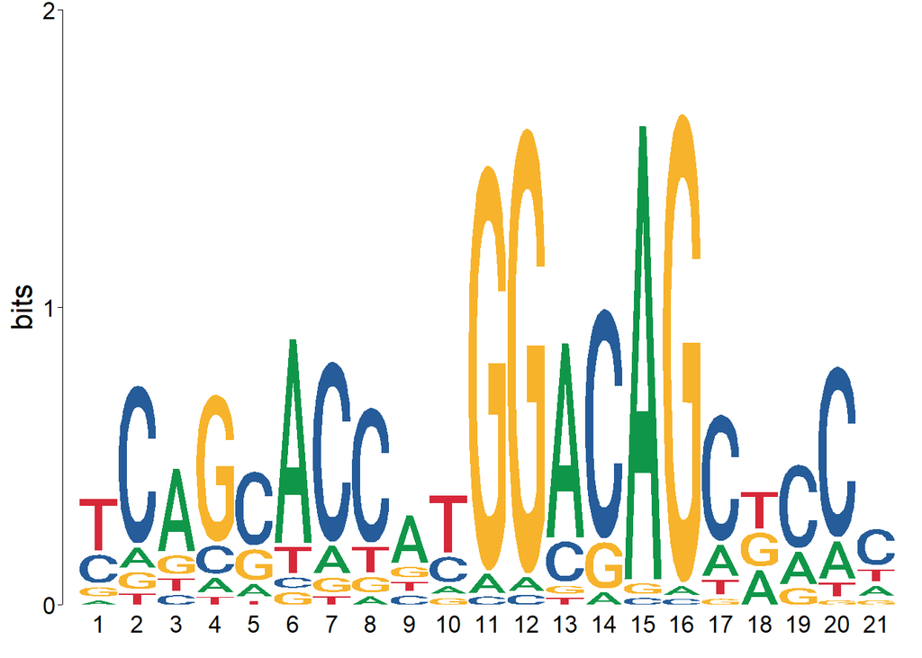

```r
motif <- motifs[["Mmusculus-HOCOMOCOv10-REST_MOUSE.H10MO.A"]]
view_motifs(motif)
```

```r
# Function doing something similar to matchMotifs
#' findMotifInstances
#'
#' A wrapper around TFBSTools for scanning motif occurence, handling the
#' coordinate conversion as `memes` does.
#'
#' @param seqs A set of sequences, e.g. `DNAStringSet`, optionally with
#'   coordinate as names to enable conversion.
#' @param motif A motif, in any format recognized by `universalmotif`
#' @param keepMatchedSeq Logical; whether to keep the matched sequence.
#' @param ... Passed to `TFBSTools::searchSeq`; can for instance be used to set
#'   the number of threads to use, e.g. with `mc.cores=2`
#'
#' @return A `GRanges` object
findMotifInstances <- function(seqs, motif, keepMatchedSeq=FALSE, ...){
  motif <- universalmotif::convert_motifs(motif, "TFBSTools-PWMatrix")
  x <- suppressWarnings(TFBSTools::searchSeq(motif, subject=seqs))
  peaks <- strsplit(gsub("-",":",names(seqs)), ":")
  if(all(lengths(peaks)==3)){ # convert relative coordinates to absolute
    chrs <- sapply(peaks,FUN=function(x) x[1])
    offsets <- sapply(peaks,FUN=function(x) as.integer(x[2]))-1L
    i <- rep(seq_along(x),lengths(x))
    return(GRanges(chrs[i],
                   IRanges(offsets[i]+as.integer(unlist(lapply(x, start))),
                           offsets[i]+as.integer(unlist(lapply(x, end)))),
                   strand=unlist(lapply(x, strand)),
                   score=as.numeric(unlist(lapply(x, FUN=function(x) score(x))))
                   ))
  }
  x <- as(x, "GRanges")
  score(x) <- x$absScore
  keepFields <- c("score","relScore")
  if(keepMatchedSeq) keepFields <- c(keepFields, "siteSeqs")
  mcols(x) <- mcols(x)[,intersect(colnames(mcols(x)), keepFields)]
  x
}
```

```r
# Scanning the peak sequences
Biostrings::writeXStringSet(rtracklayer::import(genome), "genome.fa")
motif2 <- convert_motifs(motif, class="TFBSTools-PFMatrix")
```

```
## Note: motif [motif] has an empty nsites slot, using 100.
```

```r
# moi2 <- matchMotifs(motif2, subject=peak_centers, genome=Rsamtools::FaFile("genome.fa"), out="positions")
moi2 <- findMotifInstances(motif = motif2, seqs = peak_seqs)
moi2
```

```
## GRanges object with 1850 ranges and 1 metadata column:
##          seqnames              ranges strand |     score
##             <Rle>           <IRanges>  <Rle> | <numeric>
##      [1]        2   33018215-33018235      - |   24.2295
##      [2]        2   33018236-33018256      - |   22.5839
##      [3]        9   56738447-56738467      + |   28.6767
##      [4]        9   21950525-21950545      + |   21.0179
##      [5]        9   21950501-21950521      - |   26.7610
##      ...      ...                 ...    ... .       ...
##   [1846]        1 177555830-177555850      - |   11.8344
##   [1847]        1 177555845-177555865      - |   12.9185
##   [1848]        5   92505260-92505280      - |   13.9287
##   [1849]       10   77886543-77886563      + |   17.0521
##   [1850]        3 108911430-108911450      + |   16.2781
##   -------
##   seqinfo: 20 sequences from an unspecified genome; no seqlengths
```

```r
# Scanning the entire genome sequence
Biostrings::writeXStringSet(rtracklayer::import(genome), "genome.fa")
motifg <- convert_motifs(motif, class="TFBSTools-PFMatrix")
```

```
## Note: motif [motif] has an empty nsites slot, using 100.
```

```r
moig <- findMotifInstances(motif = motifg, seqs = Biostrings::getSeq(genome))
moig
```

```
## GRanges object with 209697 ranges and 2 metadata columns:
##              seqnames          ranges strand |  relScore     score
##                 <Rle>       <IRanges>  <Rle> | <numeric> <numeric>
##        [1]          1 3044846-3044866      + |  0.802584   11.5278
##        [2]          1 3057536-3057556      + |  0.800278   11.3148
##        [3]          1 3110258-3110278      + |  0.804476   11.7024
##        [4]          1 3115472-3115492      + |  0.823156   13.4271
##        [5]          1 3123519-3123539      + |  0.872329   17.9670
##        ...        ...             ...    ... .       ...       ...
##   [209693] GL456396.1     14452-14472      - |  0.800008   11.2899
##   [209694] GL456396.1     20987-21007      - |  0.801218   11.4016
##   [209695] GL456368.1       5886-5906      + |  0.834247   14.4511
##   [209696] GL456368.1     10173-10193      + |  0.847260   15.6525
##   [209697] JH584295.1          89-109      + |  0.870352   17.7845
##   -------
##   seqinfo: 58 sequences from an unspecified genome; no seqlengths
```

# Answer the following questions

## Of all the peaks, what proportion contains a motif for the factor?

(Expected form of an answer: of the XX peaks, XX (XX%) contain a motif)

```r
PeaksOverlapsMotifs <- overlapsAny(peak_centers,moi2)
table(PeaksOverlapsMotifs)
```

```
## PeaksOverlapsMotifs
## FALSE  TRUE
##  1833  1722
```

```r
table(PeaksOverlapsMotifs)[2]/(table(PeaksOverlapsMotifs)[1]+table(PeaksOverlapsMotifs)[2])
```

```
##      TRUE
## 0.4843882
```

```r
length(peak_centers)
```

```
## [1] 3555
```

Of the 3555 peaks, 1722 (48%) contain a motif. There the motif instances where calculated only in the peak regions.

```r
PeaksOverlapsMotifsG <- overlapsAny(peak_centers,moig)
table(PeaksOverlapsMotifsG)
```

```
## PeaksOverlapsMotifsG
## FALSE  TRUE
##  1753  1802
```

```r
table(PeaksOverlapsMotifsG)[2]/(table(PeaksOverlapsMotifsG)[1]+table(PeaksOverlapsMotifsG)[2])
```

```
##      TRUE
## 0.5068917
```

```r
length(peak_centers)
```

```
## [1] 3555
```

Of the 3555 peaks, 1802 (51%) contain a motif. There the motif instances were calculated on the whole genome.

The results do not differ that much there.

## Of all instances of that motif in the genome (or in one chromosome), what proportion is bound by the factor (i.e. has a peak)?

(Expected form of an answer: of the XX motif instances, XX (XX%) overlap a peak)

```r
MotifsOverlapsPeaks <- overlapsAny(moi2,peak_centers)
table(MotifsOverlapsPeaks)
```

```
## MotifsOverlapsPeaks
## TRUE
## 1850
```

```r
table(MotifsOverlapsPeaks)[2]/(table(MotifsOverlapsPeaks)[1]+table(MotifsOverlapsPeaks)[2])
```

```
## <NA>
##   NA
```

```r
length(moi2)
```

```
## [1] 1850
```

All 1850 motifs (100%) in the peak regions are bound by the factor. There the motif instances where calculated only in the peak regions, so it makes sense that using these for the overlap calculation we obtain 100%.

```r
MotifsOverlapsPeaksG <- overlapsAny(moig,peak_centers)
table(MotifsOverlapsPeaksG)
```

```
## MotifsOverlapsPeaksG
##  FALSE   TRUE
## 207705   1992
```

```r
table(MotifsOverlapsPeaksG)[2]/(table(MotifsOverlapsPeaksG)[1]+table(MotifsOverlapsPeaksG)[2])
```

```
##        TRUE
## 0.009499421
```

```r
length(moig)
```

```
## [1] 209697
```

Of the 209697 motif instances in the genome, 1992 (0.95%) overlap a peak. There the motif instances were calculated on the whole genome, so it makes sense that there are not that many overlaps in %, and it is more interesting to know this number than the previous one.

```r
# Just to check whether I get the same result with this different formulation
length(moig[overlapsAny(moig,peak_centers)])/length(moig)
```

```
## [1] 0.009499421
```